# S35 Particle Detectors and Accelerators

## Accelerator Physics by Professor Adrian Oeftiger

[figure not shown]

### Lecture 2: Acceleration and Bunching

## Run this notebook online!

Interact and run this jupyter notebook online:

via the local Physics Jupyterlab service:

via the public mybinder.org service:

Also find this lecture rendered [as HTML slides on github $\nearrow$](https://aoeftiger.github.io/UOXF-AP-2026/) along with the [source repository $\nearrow$](https://github.com/aoeftiger/UOXF-AP-2026).

## Run this first!

Imports and modules:

```python
from config import np, plt, plot_rfwave
%matplotlib inline
```

## Refresher!

1. Intro to Accelerators
   - similarities to plasma physics, importance of external fields
   - rf cavities, dipole and quadrupole magnets
2. Accelerator Types
   - linacs, cyclotrons, synchrotrons, plasma accelerators
3. Facilities & Applications
   - light sources: Diamond
   - neutron spallation sources: ISIS
   - high-energy physics: CERN
4. Time Scales

## Today!

1. Basics: Relativistic particles in EM fields
2. RF (Radio-Frequency) Cavities
3. Longitudinal Beam Dynamics (Tracking Equations) in a Linac:
   1. Energy Gain
   2. Longitudinal Drift

## A Relativistic Particle

Relativistic particle of rest mass $m_0$ at velocity $\mathbf{v}$ features **momentum**

$$p=|\mathbf{p}|=|\gamma m_0 \mathbf{v}| = \gamma m_0 \beta c$$

where

$$\begin{cases} c&\text{: speed of light in vacuum,}\qquad &c&\doteq 2.998\times 10^8 \text{m/s} \\[0.3em] \beta&\text{: particle speed in units of }c,\qquad&\beta&\doteq |\mathbf{v}/c| < 1 \\ \gamma&\text{: relativistic Lorentz factor,}\qquad &\gamma&\doteq\cfrac{1}{\sqrt{1 - \beta^2}} > 1 \end{cases}$$

**Total energy** defined by: $\qquad E_{\text{tot}}=\gamma m_0 c^2$

and related to momentum $p$ by the **relativistic equation**: $\qquad E_{\text{tot}}^2=\bigl(m_0c^2\bigr)^2 + (pc)^2$

## Lorentz Force

Utilise electromagnetic fields $(\mathbf{E},\mathbf{B})$ to exert **Lorentz force** $\mathbf{F}_L$ on particle of charge $q$:

$$\frac{d\mathbf{p}}{dt} = \mathbf{F} = q\,(\mathbf{E}+\mathbf{v}\times\mathbf{B})$$

Deriving relativistic equation by time $t$ and using definition of $E_\text{tot}$:

$$\implies E_\text{tot} \frac{dE_\text{tot}}{dt} = c^2\cdot\mathbf{p}\cdot \frac{d\mathbf{p}}{dt} = c^2\cdot \mathbf{p}\cdot\mathbf{F}_L$$

$$\stackrel{/E_\text{tot}}{\implies} \frac{dE_\text{tot}}{dt} = \mathbf{v}\cdot\mathbf{F}_L = q\cdot \mathbf{v}\cdot(\mathbf{E}+\underbrace{\mathbf{v}\times \mathbf{B}}\limits_\text{cancels}) = q\cdot \mathbf{v}\cdot\mathbf{E}$$

**The total energy can only be increased by electric field components!**

## Frenet-Serret Coordinate System

[figure not shown]

Particle moves along reference path parametrised by length $s$ with velocity

$$\mathbf{v}_s = \frac{d\mathbf{s}}{dt}$$

Phase space coordinates with respect to reference particle at $|\mathbf{p}|=p_0$ moving with time $t$:

| Plane | Coordinate (Offset) | Momentum |
| --- | --- | --- |
| Horizontal | $x$ | $x'\doteq\frac{dx}{ds}$ |
| Vertical | $y$ | $y'\doteq\frac{dy}{ds}$ |
| Longitudinal | $z$ | $\delta\doteq\frac{p_z-p_0}{p_0}$ long. momentum deviation |

## How to Accelerate?

Let us look at how the particle energy may change along $s$.

$$\implies \frac{dE_{\mathrm{tot}}}{ds} = \frac{1}{v_s} \frac{dE_{\mathrm{tot}}}{dt} = q \cdot \frac{\mathbf{v}}{v_s}\cdot \mathbf{E} = q \cdot \Bigl(\underbrace{\frac{v_z}{v_s}}\limits_{\color{red}{\mathop{\approx}1}}E_z + \underbrace{\frac{v_x}{v_s}}\limits_{\color{red}{\mathop{\approx}\frac{dx}{ds}\mathop{\equiv}x'}}\cdot E_x + \underbrace{\frac{v_y}{v_s}}\limits_{\color{red}{\mathop{\approx}\frac{dy}{ds}\mathop{\equiv}y'}}\cdot E_y \Bigr)$$

Here "$\approx$" is referred to as $\rightarrow$ *"paraxial approximation"*.

$$\implies\left\{\begin{array}\, x',~y'&\text{: small angles (momenta)}\Leftrightarrow\text{transverse $\mathbf{E}_{x,y}$ fields $=$ weak impact} \\ E_z&\text{: longitudinal electric field most efficient to provide }\cfrac{dE_{\mathrm{tot}}}{ds} \end{array}\right.$$

## Accelerate!

3 (+1) typical ways to supply $E_z$:

1. **DC field**, single passage!  
   $\rightarrow$ electrostatic accelerators: few MV/m before breakdown
2. AC field: **travelling wave rf cavities**  
   $\rightarrow$ ultra-relativistic particles (typically electrons)
3. AC field: **resonator / standing wave rf cavities**:  
   $\rightarrow$ most versatile standard (International Linear Collider project: 35 MV/m)

(+4. **plasma wakefields**, single passage!)  
$\rightarrow$ ultra-relativistic particles (typically electrons), 100'000 MV/m

## Part I: Momentum / Energy Gain

Longitudinal phase space: $(z, {\color{red}{\delta}})$

[figure not shown]

## Standing-wave RF Cavities

Confine electromagnetic wave in a **resonating cavity** to provide oscillatory $E_z$ along axis:

$$\mathbf{E}(\mathbf{r},s,t)=E_{z,0}(\mathbf{r},s)\,\sin(\omega_\text{rf}\,t)\,\mathbf{e}_z$$

A low-power RF signal is amplified and coupled to the cavity to maintain and control amplitude of the RF wave with respect to the beam.

Exact field distribution $E_{z,0}(\mathbf{r},s)$ and RF (angular) frequency $\omega_\text{rf}=2\pi f_\text{rf}$ depend on cavity geometry. Typically TM${}_{010}$ is used as main accelerating mode for optimal $E_z$ along axis ($\Rightarrow$ magnetic field vanishes on-axis).

images by [A. Lasheen](https://indico.cern.ch/event/1607513/contributions/6773124/) and [S. Tavernier](https://link.springer.com/chapter/10.1007/978-3-642-00829-0_3)

## Example at CERN Proton Synchrotron

[figure not shown]

images by [E. Jensen](https://link.springer.com/chapter/10.1007/978-3-030-34245-6_8#Sec23) and [CERN](https://panoramas-outreach.cern.ch/viewer?fov=90&id=43087505&lat=-0.72&lon=36.00)

## RF Voltage

[figure not shown]

Consider a particle of charge $q$ travelling along cavity axis $s$ while time $t$ passes:

$$E_z(s, t) = E_{z,0}(s) \cdot \sin\bigl(\omega_{\text{rf}}\, t + \varphi_s\bigr)$$

Here, $\varphi_s$ refers to **synchronous phase** at arrival of "synchronous" reference particle. The **RF wave voltage amplitude** is given by:

$$V_0 = \int\limits_{-\infty}^{+\infty} ds\,\left|E_{z,0}(s)\right|$$

(Hypothetical) maximum energy gain of particle during passage would be $\Delta W = |q|\cdot V_0$.

## Transit-time Factor

Real energy gain for a particle $\Delta W$ reduces due to inevitable field variation during gap transit.

$\implies$ **Transit-time factor**:

$$ T = \frac{\text{energy gain of particle with }v=\beta c}{\text{maximum energy gain (particle with }v\rightarrow\infty\text{)}} \leq 1 $$

Effective RF voltage seen by particles is $V=V_0T$.

## Energy Gain by RF Cavity

Reference beam energy increases as determined by synchronous phase $\varphi_s$,

$$\Delta W_0 = q V\cdot\sin(\varphi_s)$$

Real particles travel at a longitudinal distance $z = s - \beta c t$ to synchronous particle. They experience a "kick" at phase $\varphi = \omega_{\text{rf}}\,t = \varphi_s - \cfrac{\omega_{\text{rf}} z}{\beta c}$ with an energy gain of $\Delta W = q V\cdot \sin(\varphi)$.

Expressed as an energy distance $\Delta E$ to the synchronous particle, $\Delta E=E_{\text{tot}} - E_{\text{tot},0}$, the discrete energy update of an arbitrary particle passing through an RF cavity becomes

$$\begin{align} \Delta E|_{\text{after}} &= \Delta E|_{\text{before}} + \Delta W - \Delta W_0 \\ &= \Delta E|_{\text{before}} + q V\cdot \bigl(\sin(\varphi) - \sin(\varphi_s)\bigr) \end{align}$$

## Phase or Longitudinal Focusing

$$\Delta E|_\text{after} = \Delta E|_\text{before} + q V\cdot \left(\sin\left(\varphi_s - \frac{\omega_\text{rf}z}{\beta c}\right) - \sin(\varphi_s)\right)$$

Phase focusing principle (classical regime, see later), resulting in **bunched** beam:

- particle with $\varphi>\varphi_s$ arrives later and has $\color{blue}{\delta < 0}$:  
  needs to be **ac**celerated towards synchronous particle!
- particle with $\varphi<\varphi_s$ arrives early and has $\color{orange}{\delta > 0}$:  
  needs to be **de**celerated towards synchronous particle!

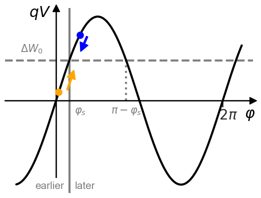

```python
plot_rfwave(phi_s=0.5); # change phi_s and explore
```

## Comprehension Questions

1. Consider an ensemble of particles distributed in $\varphi$ around the (hypothetical) synchronous particle at $\varphi_s=30\,\text{deg}$. Assume linear drifts (constant momentum) in between many rf cavities along $s$. What qualitative type of motion of the ensemble would you expect in phase space along an extended distance?
2. What would happen to a slower and faster particle, respectively, if $\varphi_s$ was moved to $\pi-\varphi_s$? How would the motion of the particle ensemble change accordingly?

## Linear Accelerators / Linacs

[figure not shown]

($x$ in the animation corresponds to our $s$)

**Drift tube linear accelerators (DTLs)** consist of many subsequent drift tubes between which the fields oscillate

- distance between two accelerating gaps depends on particle velocity $\beta c$  
  $\implies$ synchronism condition for linacs $\leftrightarrow$ length of drift tubes
- maximum energy reach scales with length of linac and rf accelerating gradient ($\approx$ MV/m)
- RF structure at high frequency provides micro-bunches

images by [Chetvorno](https://commons.wikimedia.org/wiki/File:Linear_accelerator_animation_16frames_1.6sec.gif) and [CERN](https://cds.cern.ch/record/43884/)

## Part II: Longitudinal Drift

Longitudinal phase space: $({\color{red}{z}}, \delta)$

## Drifting on a non-curved trajectory

The synchronous particle moves with $s=\beta ct$ along the reference path.

The longitudinal offset of a given real particle $z$ relates to its distance at $s$ compared to the synchronous particle after a given time $t$:

$$z=s - \beta c t$$

Consider a drift length $L_d$ (without any fields present) traversed by the synchronous particle in $T_d=\cfrac{L_d}{\beta c}$. A real particle would arrive with $T_d+\Delta t$:

$$z=L-\beta c(T_d+\Delta t)=-\beta c \Delta t$$

On a straight reference trajectory, the delay $\Delta t$ directly relates to the change in speed $\Delta\beta$:

$$\cfrac{\Delta t}{T_d} = -\cfrac{\Delta \beta}{\beta}$$

$$\implies z=-\beta c \Delta t = T_d c \Delta \beta = L_d \frac{\Delta \beta}{\beta}$$

This $\Delta\beta$ corresponds to a momentum deviation $\Delta p/p_0=\delta$ of the real particle. Using the total momentum definition and $\gamma\equiv 1/\sqrt{1-\beta^2}$,

$$p = \beta\gamma m_0 c \implies \underbrace{\frac{\Delta p}{p_0}}\limits_{\equiv \delta} = \frac{\Delta\beta}{\beta} + \underbrace{\frac{\Delta\gamma}{\gamma}}\limits_{\left(\gamma^2-1\right)\Delta\beta/\beta} = \gamma^2\cdot \frac{\Delta\beta}{\beta}$$

which yields the update relation for the offset $z$ after a longitudinal drift according to a momentum deviation $\delta$:

$$\implies z|_\text{after} = z|_\text{before}+\cfrac{L_d}{\gamma^2}\,\delta$$

## Linacs: Longitudinal Update Map I

The energy gain in the rf cavity,

$$\Delta E|_\text{after} = \Delta E|_\text{before} + q V\cdot \left(\sin\left(\varphi_s - \frac{\omega_\text{rf}z}{\beta c}\right) - \sin(\varphi_s)\right) \quad ,$$

and the longitudinal drifting, $z|_\text{after} = z|_\text{before}+\cfrac{L_d}{\gamma^2}\,\delta$, form the **discrete longitudinal update map** or **linac tracking equations** (in absence of curvature (dipoles) and other energy loss terms such as synchrotron radiation).

With $\delta = \frac{\Delta p}{p_0} = \frac{1}{p_0}\cdot \frac{\Delta E}{\beta c}$, we can express them in $(z,\delta)$ phase space coordinates in absence of acceleration ($\varphi_s=0$):

$$\delta_{n+1} = \delta_n + \cfrac{q V}{\beta c p_0}\cdot\sin\left(\varphi_s - \cfrac{\omega_\text{rf}z_{n+1}}{\beta c}\right) \quad .$$

## Linacs: Longitudinal Update Map II

With acceleration, $p_0$ changes, and it is more convenient to use $(\Delta t, \Delta E)$ or $(z,\Delta p)$ as phase space coordinates.

The **particle tracking equations** from cavity $n$ to cavity $n+1$ in a linac hence read

$$\begin{cases}\, z_{n+1} &= z_n + \cfrac{L_d}{\gamma_n^2} \left(\cfrac{\Delta p}{p_0}\right)_n \\ (\Delta p)_{n+1} &= (\Delta p)_n + \cfrac{q V}{(\beta c)_n}\cdot\left(\sin\left(\varphi_s - \cfrac{\omega_\text{rf}z_{n+1}}{\beta c}\right) - \sin(\varphi_s)\right) \end{cases}$$

with the synchronous phase $\varphi_s$ determined by $(\delta p_0)_{\text{turn}} = \frac{q V}{\beta c}\,\sin\bigl(\varphi_s\bigr)$.

## Part III: Tracking Example in CERN LINAC4

Longitudinal particle tracking in a linear accelerator

## LINAC4 as first proton injector

[figure not shown]

images by [R. Hradil](https://cds.cern.ch/record/2260707) and [CERN](http://cds.cern.ch/images/CERN-GRAPHICS-2022-001-1)

## LINAC4 Features

- 86m long staged linear accelerator delivering H${}^-$ ion beams at 160 MeV
- Accelerates from the source to the first synchrotron, the PS Booster
- Operates since 2020 as first stage to produce beams for the LHC, key element of LHC High Luminosity Upgrade

[figure not shown]

The 19m long DTL section has 3 tanks with a total of 111 drift tubes:

- accelerate from $E_\text{kin}=$ **3 MeV to 50 MeV**
- RF frequency at $f_\text{RF}=$ **352 MHz**
- RF voltage per gap $V\approx$ **0.5 MV/m**
- synchronous phase $\varphi_s\approx$ **70 deg**

## Gap voltage and synchronous phase (Linac convention)

The DTL corresponds to the first 111 data points (see red label):

[figure not shown]

NB: linacs often use the cosine phase convention, $\Delta W_0 = q V\cdot\cos(\varphi_s)$, while we stick to $\Delta W_0 = q V\cdot\sin(\varphi_s)$ throughout this course.

$\implies$ translate y-axis of right plot from $\varphi$ to $\varphi+90\deg$ for our convention!

figures by [A.M. Lombardi et al.](https://proceedings.jacow.org/HB2008/papers/wgb14.pdf)

## Simplistic Tracking Example

Let us track a bunch of H${}^-$ particles through the DTL!

First compute the initial Lorentz factor $\gamma$ at the start of the DTL – remember to use SI units throughout:

```python
from scipy.constants import m_p, e, c

charge = -e #fill me
mass = m_p #fill me

gamma_ini = 1 + 1/(mass * c**2) * 3e6 * e #fill me
gamma_ini
```

```
1.0031973667700465
```

Some convenience functions to compute the speed β and the relativistic Lorentz factor γ:

```python
def beta(gamma):
    '''Speed β in units of c from relativistic Lorentz factor γ.'''
    return np.sqrt(1 - gamma**-2)

def gamma(p):
    '''Relativistic Lorentz factor γ from total momentum p.'''
    return np.sqrt(1 + (p / (mass * c))**2)
```

What is the RF wavelength of LINAC4?

```python
lambda_rf = c / 352e6 #fill me
lambda_rf
```

```
0.8516831193181819
```

How long would you expect a bunch of particles to be?

```python
bunch_length = 1e-3 #fill me
bunch_length
```

```
0.001
```

Fill in the missing parameters to define the Linac `machine` object:

```python
class Machine(object):
    # units: SI, phi_s in rad:
    gamma_ref = gamma_ini #fill me
    total_length = 19. #fill me
    n_drifts = 111 #fill me
    voltage = 0.5e6 #fill me
    frequency = 352e6 #fill me
    phi_s = -70 * np.pi/180

    def p0(self):
        '''Momentum of synchronous particle.'''
        return self.gamma_ref * beta(self.gamma_ref) * mass * c

    def update_gamma_ref(self):
        '''Advance the energy of the synchronous particle
        according to the synchronous phase by one cavity kick.
        '''
        deltap_per_turn = charge * self.voltage / (
            beta(self.gamma_ref) * c) * np.sin(self.phi_s)
        new_p0 = self.p0() + deltap_per_turn
        self.gamma_ref = gamma(new_p0)

    def reset(self):
        self.gamma_ref = gamma_ini
```

This is our tracking function which advances the particles by one drift tube and a gap:

```python
def track_one_tube(z_n, deltap_n, machine):
    m = machine
    Ld = m.total_length / m.n_drifts
    # drift
    z_n1 = z_n - Ld / m.gamma_ref**2 * deltap_n / m.p0()
    # rf kick
    amplitude = charge * m.voltage / (beta(gamma(m.p0())) * c)
    phi = m.phi_s - 2 * np.pi * m.frequency * z_n1 / (beta(gamma(m.p0())) * c)

    deltap_n1 = deltap_n + amplitude * (np.sin(phi) - np.sin(m.phi_s))
    m.update_gamma_ref()
    return z_n1, deltap_n1
```

The `Machine` instance will keep track of the reference energy during the tracking by calling `update_gamma_ref()` once per rf cavity kick:

```python
m = Machine()
```

Particles are tracked by their two longitudinal coordinates $(z, \Delta p)$. The initial values are stored in `z_ini` and `deltap_ini` as `numpy.array`s. These should have `N` entries for $N$ particles.

(You may use numpy helper functions such as `np.linspace` or `np.arange` for convenient initialisation!)

```python
z_ini = np.linspace(-bunch_length/2, bunch_length/2, 50)
deltap_ini = np.zeros_like(z_ini)

N = len(z_ini)
assert (N == len(deltap_ini))
```

To store the coordinate values during tracking, prepare some `n_drifts` long 2D arrays with `N` entries per turn:

```python
z = np.zeros((m.n_drifts, N), dtype=np.float64)
deltap = np.zeros_like(z)

z[0] = z_ini
deltap[0] = deltap_ini
```

We would also like to store the reference beta for each turn:

```python
betas = np.zeros(m.n_drifts, dtype=np.float64)
betas[0] = beta(m.gamma_ref)
```

## Tracking Loop!

Let's go, here's the tracking loop along the DTL!

```python
m.reset()

for i_turn in range(1, m.n_drifts):
    z[i_turn], deltap[i_turn] = track_one_tube(z[i_turn - 1], deltap[i_turn - 1], m)
    betas[i_turn] = beta(m.gamma_ref)
```

Check: did we reach the (correct) final energy?

```python
"Ekin = {:.2e} eV".format((m.gamma_ref - 1) * mass * c**2 / e)
```

```
'Ekin = 5.50e+07 eV'
```

## Change of speed along DTL

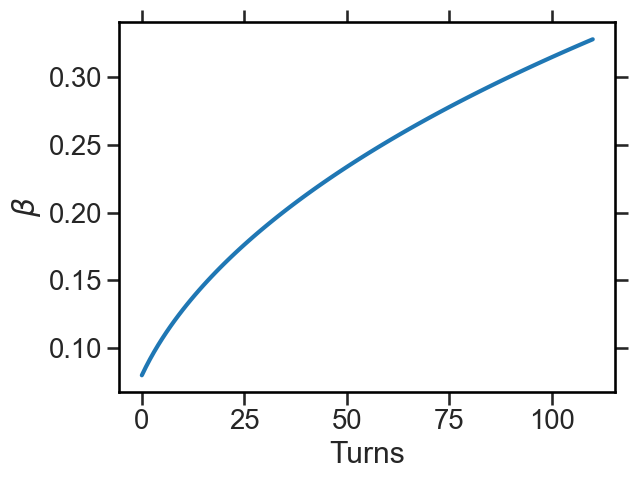

```python
plt.plot(betas)
plt.xlabel('Turns')
plt.ylabel(r'$\beta$');
```

## Phase space portrait of particles along DTL

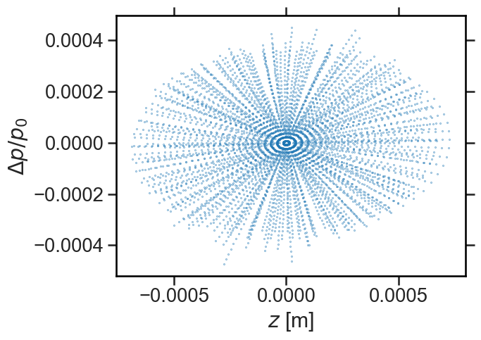

```python
plt.scatter(z, deltap / m.p0(), marker='.', s=0.5)
plt.xlabel('$z$ [m]')
plt.ylabel('$\Delta p/p_0$')
```

## Questions about Longitudinal Dynamics Linac Model

1. Which parameter do we need to adjust to accelerate to $\approx$ 50 MeV?  
   (Given the sign of the H${}^-$ particle charge, in which direction do you change that parameter?)
2. What type of particle motion are we observing?
3. What happens if you increase the bunch length significantly (approaching the RF wavelength)?
4. What could you do to further increase the acceleration rate? Observe what happens to the stability of the particles if you increase the synchronous phase $\varphi_s$?
5. Which part of this Linac longitudinal dynamics model is overly simplistic?

## Summary

- Lorentz force, longitudinal $E_z$ field component only means to accelerate
- transit-time factor
- energy gain in rf cavity: synchronous particle and real particles
- linacs
- phase focusing and stability $=$ bunching
- longitudinal particle tracking equations for linacs

## Some considerations on rf cavity modelling for reference

## Approximation #1: Velocity Change

*A priori*, energy gain is associated with particle velocity change, i.e. exact $T$ depends on $d\beta$ during passage through rf cavity.

For medium-energy linacs and synchrotrons, effect of velocity change can be neglected to determine energy gain ($\Delta W\propto\Delta\gamma$):

$$\frac{d\beta}{\beta} = \frac{1}{\beta^2\gamma^2} \cdot \frac{d\gamma}{\gamma}$$

$\implies$ two scenarios where approximation of $T$ independence of $\Delta\beta$ applies:

$$\begin{cases}\, \gamma \gg 1 &:\quad\text{particle is already ultra-relativistic} \\[0.3em] \Delta\gamma \ll \beta\gamma &:\quad\text{cavity energy gain much smaller than particle momentum} \end{cases}$$

## Simple Example for $T$

Consider *uniform* standing wave with $E_{z,0}(s)=V_0/g=\mathrm{const}$ across gap width $g$ (zero field outside), at crest of rf wave, i.e. $\varphi_s=\pi/2$:

$$E_z(s, t) = \frac{V_0}{g} \,\cos(\omega_{\text{rf}}\,t)$$

The synchronous particle travels along $s=\beta c t$ (assuming constant $v=\beta c$) and picks up an actual maximum energy gain

$$\implies \Delta W = \cfrac{q V_0}{g}\int\limits_{-g/2}^{+g/2} ds\cdot \cos\left(\cfrac{\omega_{\text{rf}}\,s}{\beta c}\right)$$

and the transit-time factor becomes:

$$T = \left| \cfrac{\sin\left(\cfrac{\omega_\text{rf} g}{2\beta c}\right)}{\cfrac{\omega_{\text{rf}} g}{2\beta c}} \right| \quad \implies\quad T\rightarrow 1 \Leftrightarrow \begin{cases}\, g \rightarrow 0 \\ \omega_{\text{rf}} \rightarrow 0 \\ \beta c \rightarrow \infty \end{cases}$$

$\implies$ reduction in effective energy gain ($T<1$) is mostly relevant for low-energy protons and ions!

## Earnshaw's Theorem

"A charged body cannot be held in stable equilibrium by electrostatic forces from other charged bodies."

S. Earnshaw (1839), Trans. Camb. Phil. Soc. **7** 97

$\implies$ application to rf accelerators: always one direction in 3D which is defocused!

## Approximation #2: Transverse Defocusing

[figure not shown]

Real $\mathbf{E}$ field across gap in rf cavities has transverse component when off axis, classical regime:

- focusing at entry
- defocusing at exit

$\implies$ DC field leads to net focusing effect (due to gain in longitudinal momentum), but AC field in case of stable longitudinal motion: net defocusing effect (rise in voltage during passage)

$\implies$ typically very weak vs. quadrupole fields and, in synchrotron models, often neglected